# Run EconML: year 2008-2015

Shunkei Kakimoto

# 1 Objective

- Using *CF*, measure of ‘importance’ for each feature.
- Apply *Double Machine Learning(DML) ORF* and *CF of grf* to the newly created dataset.
  - include year FE and individual FE
    - create year dummy dummies and include then as controls(?)
- visualize the effects of each variables
  - soil
    - sandtotal_r, claytotal_r, silttotal_r, ksat_r, awc_r, slope_r
  - weather
    - pr_in, pet_in, gdd_in

# 2 Set up

```r
# library(here)
# setwd(here())

# /*===== R =====*/
source("./GitControlled/Codes/0_1_ls_packages.R")
source("./GitControlled/Codes/0_0_functions.R")


# /*===== python  =====*/
use_python("./myenv/bin/python")
use_virtualenv("./myenv/bin/activate_this.py")

source_python("./GitControlled/Codes/0_0_import_modules.py")
# source_python("./GitControlled/Codes/0_0_functions.py")

# /*===== Data (stage3, 2008- )=====*/
# --- panel data--- #
reg_data <- readRDS("./Shared/Data/WaterAnalysis/comp_reg_dt.rds") %>%
  # (what if I change to 100?)
  .[year>=2008 & usage <= 40,]
```

# 3 Preparation

- Create training and testing dataset
- include year FEs and individual FEs (from *panel_fe_dmlof.rmd*)
  - run `feols(usage ~ 1 | wellid + year, data = reg_data)` and extract the coefficients of year FEs and individual FEs
    - those coefficients can be regarded as the unique impact associated with each individual and year.

## 3.1 Variables to be included

```r
# /*===== control variables =====*/
cov_ls <- c(
    # --- weather --- #
    "pr_in", "gdd_in","pet_in",
    # --- soil --- #
  "silttotal_r", "claytotal_r", "slope_r", "ksat_r", "awc_r"
  )

all_vars <- c(cov_ls, 'usage', 'treat2', 'tr', 'year')
```

## 3.2 Training Data

```r
# /*===== find individual FE and year FE  =====*/
library(fixest)

fe_res <-
  feols(usage ~ 1 | wellid + year, data = reg_data) %>%
  fixef()

year_fe <-
  data.table(
    year = names(fe_res$year) %>% as.numeric(),
    year_fe = fe_res$year
  )

ind_fe <-
  data.table(
    wellid = names(fe_res$wellid) %>% as.numeric(),
    ind_fe = fe_res$wellid
  )

fe_data <-
  CJ(
    wellid = names(fe_res$wellid) %>% as.numeric,
    year = 2007:2015
  ) %>%
  year_fe[., on = "year"] %>%
  ind_fe[., on = "wellid"]

reg_data_fe <-
  fe_data[reg_data, on = c("year", "wellid")]
```

# 4 CF analysis

- check the impacts of each covariates with CF
- know the potential variables that create heterogeneity
  - check the variable of importance
  - based on this information, I decide which variables to be used for controls or heterogeneous drivers.
- **Further work**: read [this website](https://econml.azurewebsites.net/spec/estimation/dml.html#what-is-it)
  - ? `CF of grf` v.s. `CausalForestDML`
  - Question: Different from DML methods, CF of grf does not allow to use different covariates for heterogeneity drivers and controls.
    - I want to use `ind_fe` and `year_fe`, just as control variables (only in the first stage regression (nuisance) model)
  - We could use `feature_importances` of `CausalForestDML` to understand the important covariates

```r
# /*===== Training Dataset  =====*/
# --- dependent variable --- #
Y <- reg_data_fe[, usage]
# --- treatment indicator --- #
T <- reg_data_fe[, treat2]
# --- features --- #
X <- reg_data_fe[, c(cov_ls, "ind_fe", "year_fe"), with=FALSE]
# X <- reg_data_fe[, ..cov_ls]
# --- cluster  --- #
cl_var <-
  data.table::copy(reg_data_fe) %>%
  .[,tr_year:=factor(paste0(tr,year))] %>%
  .[,tr_year]

# /*===== Run CF =====*/
forest_W <- boosted_regression_forest(X, T, tune.parameters = "all")
W_hat <- predict(forest_W)$predictions
forest_Y <- boosted_regression_forest(X, Y, tune.parameters = "all")
Y_hat <- predict(forest_Y)$predictions

res_cf <- causal_forest(
  X=X, Y=Y, W=T,
  Y.hat = Y_hat,
  W.hat = W_hat,
  clusters = cl_var,
  tune.parameters = "all",
)

# /*===== variable of importance  =====*/
var_imp <-
  data.frame(
  name = c(cov_ls, "year_fe", "ind_fe"),
  value = variable_importance(res_cf)[,1]
) %>%
arrange(desc(value))

gt(var_imp)
```

[output not shown]

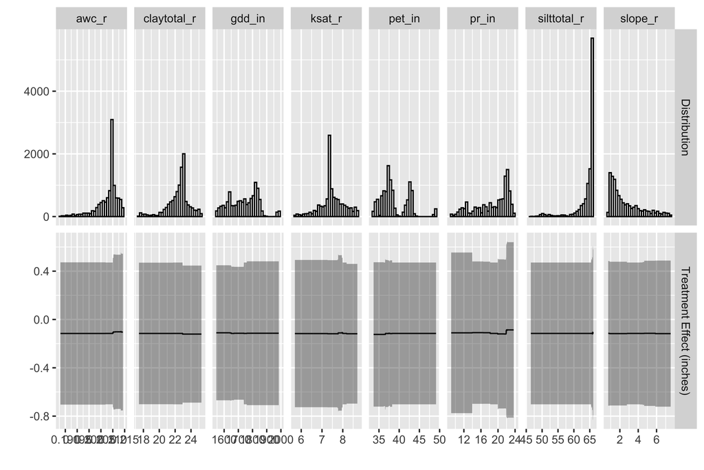

```r
# /*===== Visualization: TE estimates =====*/
gen_impact_viz(
  cf_res= res_cf,
  data_base=reg_data_fe,
  treat_var='treat2',
  var_ls= c(cov_ls, "year_fe", "ind_fe"),
  var_ls_int = cov_ls
  # var_ls= cov_ls
)
```

# 5 DML-OrthoForest analysis

## 5.1 Training Data

```r
het_vars <- c("pr_in", "gdd_in", "pet_in")

# --- dependent variable --- #
Y <- reg_data_fe[, usage] %>% as.array()
# --- treatment indicator --- #
T <- reg_data_fe[, treat2] %>% as.array()
# --- heterogeneous impact dirivers --- #
X <- reg_data_fe[, ..het_vars] %>% as.matrix()
# --- controls --- #
W <- reg_data_fe[,c(cov_ls, "year_fe", "ind_fe"), with=FALSE] %>%
  as.matrix()
```

## 5.2 Testing Data

```r
X_test_comp <-
  lapply(het_vars, function(x) gen_pred_data(reg_data_fe, het_vars, x)) %>%
  bind_rows()

X_test <-
  X_test_comp[,!"target_var"] %>%
  as.matrix()
```

## 5.3 Run DML-OrthoForest

```r
# source_python("./GitControlled/Codes/0_0_functions.py")
# source_python("./GitControlled/Codes/run_DML_OF.py")

# res_dmlof <-
#   run_DML_OF(
#     Y = Y,
#     T = T,
#     X = X,
#     W = W,
#     X_test = X_test,
#     n_trees=500,
#     min_leaf_size=20,
#     max_depth=50,
#     subsample_ratio=0.7,
#     lambda_reg=0.33
# )
```

- **Error**: Error in py_call_impl(callable, dots$args, dots$keywords) : TypeError: ‘float’ object cannot be interpreted as an integer

```python
# repl_python()
lambda_reg=0.33

est = DMLOrthoForest(
    n_trees=1000,
    min_leaf_size=20,
    max_depth=50,
    subsample_ratio=0.7,
    model_T=Lasso(alpha=lambda_reg),
    model_Y=Lasso(alpha=lambda_reg),
    model_T_final=WeightedLasso(alpha=lambda_reg),
    model_Y_final=WeightedLasso(alpha=lambda_reg),
    global_residualization=False
    )

est.fit(r.Y, r.T, X=r.X, W=r.W)
```

```python
treatment_effects = est.effect(r.X_test)
```

```python
te_lower, te_upper = est.effect_interval(r.X_test)
```

## 5.4 Visualization

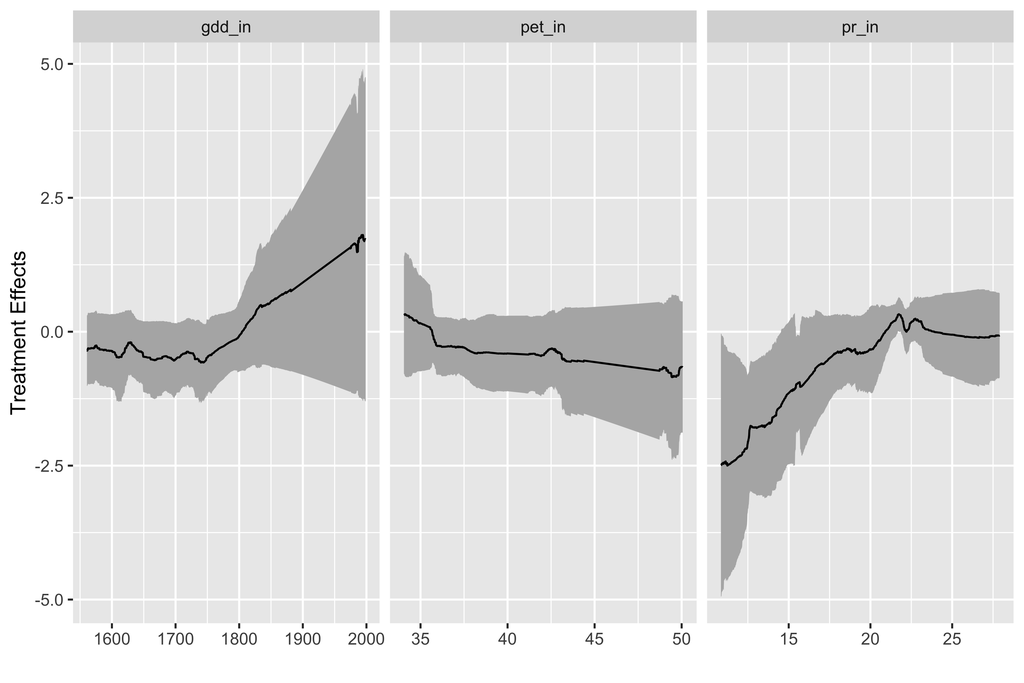

```r
res_dml_orf <-
  data.table(
    te_pred = py$treatment_effects,
    te_lower = py$te_lower,
    te_upper = py$te_upper
  ) %>%
  cbind(X_test_comp, .)

gen_econml_vis(res_econml_dt=res_dml_orf, het_vars =het_vars)
```

- The impact of the regulation varies with `gdd_in`, `pet_in`, and `pr_in`
- GDD (indicator for heat accumulation, or plants’ pace toward maturity) increases the positive impact of the treatment.
  - Around the gdd value of 1800, the treatment effects turn out to be positive
- In the regions where pet (potential evapotranspiration) is high, which means that the potential amount of water released from the land surface is large, the regulation constrains irrigation activity more
- In the regions where the amount of precipitation is relatively low, the regulation constrains irrigation activity more
  - Interestingly, the marginal impact of precipitation seems to diminish as precipitation increases
- **Further work**
  - check how those climate variables varies by regions?
    - is there any regional tendency?